# NYPD Shooting Incident Report

2023-10-04

## About This Report

The data that is use for this report is NYPD Shooting Incident Data (Historic). You can follow this link to find the data : https://data.cityofnewyork.us/api/views/833y-fsy8/rows.csv?accessType=DOWNLOAD. This data is a breakdown of every shooting incident that occurred in NYC going back to 2006 through the end of the previous calendar year.

This project focuses on the victims of the cases. Are there more victims from one ethnic group than the others? Do more people get shot in some months than the others? Which area of NYC has the largest number of shooting incident? I hope reading through this report can give you a basic concept of all these questions.

### Inporting Data

First, we import the data.

```r
url_in <- "https://data.cityofnewyork.us/api/views/833y-fsy8/rows.csv?accessType=DOWNLOAD"
cases <- read_csv(url_in, show_col_types = FALSE)
```

Now, we have the raw data. Let’s take a look at the summary of the raw data.

```
##   INCIDENT_KEY        OCCUR_DATE         OCCUR_TIME           BORO
##  Min.   :  9953245   Length:27312       Length:27312      Length:27312
##  1st Qu.: 63860880   Class :character   Class1:hms        Class :character
##  Median : 90372218   Mode  :character   Class2:difftime   Mode  :character
##  Mean   :120860536                      Mode  :numeric
##  3rd Qu.:188810230
##  Max.   :261190187
##
##  LOC_OF_OCCUR_DESC     PRECINCT      JURISDICTION_CODE LOC_CLASSFCTN_DESC
##  Length:27312       Min.   :  1.00   Min.   :0.0000    Length:27312
##  Class :character   1st Qu.: 44.00   1st Qu.:0.0000    Class :character
##  Mode  :character   Median : 68.00   Median :0.0000    Mode  :character
##                     Mean   : 65.64   Mean   :0.3269
##                     3rd Qu.: 81.00   3rd Qu.:0.0000
##                     Max.   :123.00   Max.   :2.0000
##                                      NA's   :2
##  LOCATION_DESC      STATISTICAL_MURDER_FLAG PERP_AGE_GROUP
##  Length:27312       Mode :logical           Length:27312
##  Class :character   FALSE:22046             Class :character
##  Mode  :character   TRUE :5266              Mode  :character
##
##
##
##
##    PERP_SEX          PERP_RACE         VIC_AGE_GROUP        VIC_SEX
##  Length:27312       Length:27312       Length:27312       Length:27312
##  Class :character   Class :character   Class :character   Class :character
##  Mode  :character   Mode  :character   Mode  :character   Mode  :character
##
##
##
##
##    VIC_RACE           X_COORD_CD        Y_COORD_CD        Latitude
##  Length:27312       Min.   : 914928   Min.   :125757   Min.   :40.51
##  Class :character   1st Qu.:1000028   1st Qu.:182834   1st Qu.:40.67
##  Mode  :character   Median :1007731   Median :194487   Median :40.70
##                     Mean   :1009449   Mean   :208127   Mean   :40.74
##                     3rd Qu.:1016838   3rd Qu.:239518   3rd Qu.:40.82
##                     Max.   :1066815   Max.   :271128   Max.   :40.91
##                                                        NA's   :10
##    Longitude        Lon_Lat
##  Min.   :-74.25   Length:27312
##  1st Qu.:-73.94   Class :character
##  Median :-73.92   Mode  :character
##  Mean   :-73.91
##  3rd Qu.:-73.88
##  Max.   :-73.70
##  NA's   :10
```

### Cleaning Data

Here, we remove the columns that are not needed.

```r
cases <- cases %>%
  select(-c(LOC_OF_OCCUR_DESC,LOC_CLASSFCTN_DESC,LOCATION_DESC,PERP_AGE_GROUP,
            PERP_SEX,PERP_RACE,X_COORD_CD,Y_COORD_CD,Latitude,Longitude,
            Lon_Lat,JURISDICTION_CODE))
```

Let’s take a look at the data again.

```
## # A tibble: 27,312 × 9
##    INCIDENT_KEY OCCUR_DATE OCCUR_TIME BORO     PRECINCT STATISTICAL_MURDER_FLAG
##           <dbl> <chr>      <time>     <chr>       <dbl> <lgl>
##  1    228798151 05/27/2021 21:30      QUEENS        105 FALSE
##  2    137471050 06/27/2014 17:40      BRONX          40 FALSE
##  3    147998800 11/21/2015 03:56      QUEENS        108 TRUE
##  4    146837977 10/09/2015 18:30      BRONX          44 FALSE
##  5     58921844 02/19/2009 22:58      BRONX          47 TRUE
##  6    219559682 10/21/2020 21:36      BROOKLYN       81 TRUE
##  7     85295722 06/17/2012 22:47      QUEENS        114 FALSE
##  8     71662474 03/08/2010 19:41      BROOKLYN       81 TRUE
##  9     83002139 02/05/2012 05:45      QUEENS        105 FALSE
## 10     86437261 08/26/2012 01:10      QUEENS        101 FALSE
## # ℹ 27,302 more rows
## # ℹ 3 more variables: VIC_AGE_GROUP <chr>, VIC_SEX <chr>, VIC_RACE <chr>
```

By looking at the table, we can find that the date is still in `<chr>`, let’s change it to `<date>`.

```r
cases <- cases %>%
  mutate(OCCUR_DATE = mdy(OCCUR_DATE))
```

The variables `BORO,VIC_AGE_GROUP,VIC_SEX,VIC_RACE` are still `<chr>`, which is not convenience for the future use. Let us change them to factors.

```r
cases <- cases %>%
  mutate(BORO = as.factor(BORO)) %>%
  mutate(VIC_AGE_GROUP = as.factor(VIC_AGE_GROUP)) %>%
  mutate(VIC_SEX = as.factor(VIC_SEX)) %>%
  mutate(VIC_RACE = as.factor(VIC_RACE))
```

Let’s look at the data one more time.

```
##   INCIDENT_KEY         OCCUR_DATE          OCCUR_TIME
##  Min.   :  9953245   Min.   :2006-01-01   Length:27312
##  1st Qu.: 63860880   1st Qu.:2009-07-18   Class1:hms
##  Median : 90372218   Median :2013-04-29   Class2:difftime
##  Mean   :120860536   Mean   :2014-01-06   Mode  :numeric
##  3rd Qu.:188810230   3rd Qu.:2018-10-15
##  Max.   :261190187   Max.   :2022-12-31
##
##             BORO          PRECINCT      STATISTICAL_MURDER_FLAG VIC_AGE_GROUP
##  BRONX        : 7937   Min.   :  1.00   Mode :logical           <18    : 2839
##  BROOKLYN     :10933   1st Qu.: 44.00   FALSE:22046             1022   :    1
##  MANHATTAN    : 3572   Median : 68.00   TRUE :5266              18-24  :10086
##  QUEENS       : 4094   Mean   : 65.64                           25-44  :12281
##  STATEN ISLAND:  776   3rd Qu.: 81.00                           45-64  : 1863
##                        Max.   :123.00                           65+    :  181
##                                                                 UNKNOWN:   61
##  VIC_SEX                             VIC_RACE
##  F: 2615   AMERICAN INDIAN/ALASKAN NATIVE:   10
##  M:24686   ASIAN / PACIFIC ISLANDER      :  404
##  U:   11   BLACK                         :19439
##            BLACK HISPANIC                : 2646
##            UNKNOWN                       :   66
##            WHITE                         :  698
##            WHITE HISPANIC                : 4049
```

We notice that in the `VIC_AGE_GROUP`. There is one factor that shows the age as 1022, which is impossible. As a typo, we should change it to `UNKNOWN`.

```r
cases$VIC_AGE_GROUP[cases$VIC_AGE_GROUP == '1022'] = "UNKNOWN"
cases$VIC_AGE_GROUP = droplevels(cases$VIC_AGE_GROUP)
```

```
##   INCIDENT_KEY         OCCUR_DATE          OCCUR_TIME
##  Min.   :  9953245   Min.   :2006-01-01   Length:27312
##  1st Qu.: 63860880   1st Qu.:2009-07-18   Class1:hms
##  Median : 90372218   Median :2013-04-29   Class2:difftime
##  Mean   :120860536   Mean   :2014-01-06   Mode  :numeric
##  3rd Qu.:188810230   3rd Qu.:2018-10-15
##  Max.   :261190187   Max.   :2022-12-31
##
##             BORO          PRECINCT      STATISTICAL_MURDER_FLAG VIC_AGE_GROUP
##  BRONX        : 7937   Min.   :  1.00   Mode :logical           <18    : 2839
##  BROOKLYN     :10933   1st Qu.: 44.00   FALSE:22046             18-24  :10086
##  MANHATTAN    : 3572   Median : 68.00   TRUE :5266              25-44  :12281
##  QUEENS       : 4094   Mean   : 65.64                           45-64  : 1863
##  STATEN ISLAND:  776   3rd Qu.: 81.00                           65+    :  181
##                        Max.   :123.00                           UNKNOWN:   62
##
##  VIC_SEX                             VIC_RACE
##  F: 2615   AMERICAN INDIAN/ALASKAN NATIVE:   10
##  M:24686   ASIAN / PACIFIC ISLANDER      :  404
##  U:   11   BLACK                         :19439
##            BLACK HISPANIC                : 2646
##            UNKNOWN                       :   66
##            WHITE                         :  698
##            WHITE HISPANIC                : 4049
```

Before our data is ready to use, let’s see if there is any missing data.

```r
cat('The number of missing data is',sum(is.na(cases)))
```

```
## The number of missing data is 0
```

Now since the number of missing data is 0, our data is finally ready to be used.

### Visualizing Data

Here we summarize the number of shooting incidents by area and see if there are areas have more incidents when the others.

```r
cases_by_area <- cases %>%
  group_by(BORO) %>%
  summarize(num_cases = length(INCIDENT_KEY)) %>%
  select(everything()) %>%
  ungroup()
```

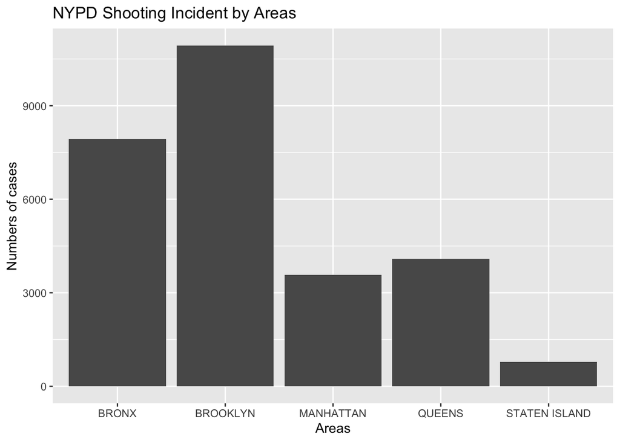

```r
p <- ggplot(data = cases_by_area, aes(x=BORO, y=num_cases)) + geom_bar(stat = "identity") +
  labs(y="Numbers of cases", x = "Areas", title = "NYPD Shooting Incident by Areas")
p
```

As we can see from the bar chart, Bronx and Brooklyn have more shooting incidents than the other areas of New York.

Now we group the cases by race and see which races have larger numbers of shooting incidents than the others.

```r
cases_by_race <- cases%>%
  group_by(VIC_RACE) %>%
  summarize(num_cases = length(INCIDENT_KEY)) %>%
  select(everything()) %>%
  ungroup()
```

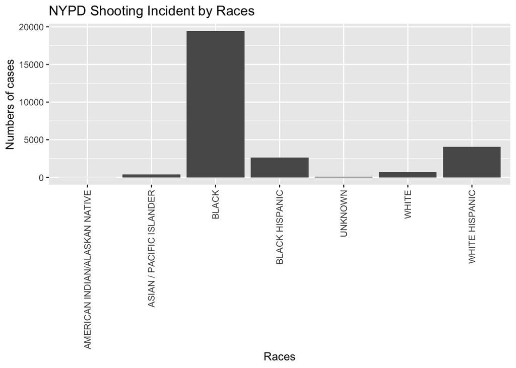

```r
p <- ggplot(data = cases_by_race, aes(x=VIC_RACE, y=num_cases)) +
  geom_bar(stat = "identity") +
  labs(y="Numbers of cases", x = "Races",
       title = "NYPD Shooting Incident by Races") +
  theme(axis.text.x = element_text(angle = 90, vjust = 0.5, hjust=1))
p
```

From this chart, it is easy to tell that most of the victims are black.

### Conclusion from Visualizations

From our observation, most of the victims are black people and people from Bronx and Brooklyn. This raised additional question that are there higher rate of black people in this two areas than the others?

The bias in our data is that, New York City has 23.4% of black people, along with 39.8% of white and others ethnic group. So we can not draw the conclusion that black people have higher chance of being the victims of shooting incidents if we don’t think about the population of each ethnic group. Also, Bronx and Brooklyn has higher density of population, it is unfair to say that these two areas have higher crime rate based on our data.

### Making Models

Let’s make a model to tell the relation between month and number of incidents. To do that, we need to group all the cases by month first.

```r
# Group incidents by each month
cases_by_month <- cases%>%
  group_by(month = lubridate::floor_date(OCCUR_DATE, 'month')) %>%
  summarize(num_cases = length(INCIDENT_KEY)) %>%
  select(everything()) %>%
  mutate(month = format(month, "%m")) %>%
  ungroup()
```

Now, we can make the model.

```r
model = lm(num_cases ~ month, data = cases_by_month)
model
```

```
##
## Call:
## lm(formula = num_cases ~ month, data = cases_by_month)
##
## Coefficients:
## (Intercept)      month02      month03      month04      month05      month06
##     100.941      -22.118       -1.647       15.706       50.294       65.471
##     month07      month08      month09      month10      month11      month12
##      89.529       84.706       50.353       33.118       13.412       16.471
```

Let’s check whether the model is good enough to be used.

```r
summary(model)
```

```
##
## Call:
## lm(formula = num_cases ~ month, data = cases_by_month)
##
## Residuals:
##     Min      1Q  Median      3Q     Max
## -93.647 -29.809   4.706  26.779 134.529
##
## Coefficients:
##             Estimate Std. Error t value Pr(>|t|)
## (Intercept)  100.941      9.965  10.129  < 2e-16 ***
## month02      -22.118     14.093  -1.569 0.118199
## month03       -1.647     14.093  -0.117 0.907084
## month04       15.706     14.093   1.114 0.266480
## month05       50.294     14.093   3.569 0.000453 ***
## month06       65.471     14.093   4.646 6.28e-06 ***
## month07       89.529     14.093   6.353 1.50e-09 ***
## month08       84.706     14.093   6.011 9.14e-09 ***
## month09       50.353     14.093   3.573 0.000446 ***
## month10       33.118     14.093   2.350 0.019792 *
## month11       13.412     14.093   0.952 0.342464
## month12       16.471     14.093   1.169 0.243970
## ---
## Signif. codes:  0 '***' 0.001 '**' 0.01 '*' 0.05 '.' 0.1 ' ' 1
##
## Residual standard error: 41.09 on 192 degrees of freedom
## Multiple R-squared:   0.42,  Adjusted R-squared:  0.3868
## F-statistic: 12.64 on 11 and 192 DF,  p-value: < 2.2e-16
```

Here we can see that the p_value is small enough to say that this model is good enough to describe the relation between month and number of incident.